# Data Pre-processing and Cleaning in R:Step-by-Step Tutorial

Matteo Manca

2016-02-21

## Introduction and usefull functions

- R is case sensitive : `VARIABLE` is different from `variable`
- All R functions have some mandatory parameters and some optional parameters.
- Use `?function` or `help(function)` to get help for a specified `function` *Each time you need to use a new function, first check how it works and which are all possible parameters*.
- During the Pre-processing and data cleaning verify often temporary results to see if your doing right
- *c(v1,v2,…)*: Create a vector (A vector is a sequence of data elements of the same basic type - numeric, char, etc. )

## Introduction

- Create a directory where you’ll store all files of this tutorial (this will be your working directory -WD-)
- Open RStudio
- Create new RScript and save it your directory WD
- Set your working directory

```
setwd("PATH_OF_YOUR_WD")
setwd("C:/Users/User Name/Documents/FOLDER")
```

```r
setwd("~/Dropbox/Sync/Research-Projects/Courses/tutorial/")
```

## Datasets

A *data set* is a collection of data that describes attribute values (variables) of a number of real-world objects (units).

- Create a new *data frame* (In R a data frame is an object used to store data. It is a list of (column) vectors of equal length. )
- create a vector for each column: `vector <- c(value1, value2, ...) = creates a vector with specified values`
- create the dataset from the just created vectors

```r
person <- c("Matteo","Jhon", "Alice","Maria") #Vector of person names
age <- c(18, NA, 22,15) #Vector of person ages
gender <- c("M","M","F","F")
df1 <- data.frame(person, age, gender) #Create the dataframe with the vecto data
```

## Explore the Datasets

- *head()/tail()* Returns the first or last parts of a vector, matrix, table, data frame or function
- *summary()* Produce result summaries of the results of various model fitting function
- try the ``?head``` command

```r
head(df1)
```

```
##   person age gender
## 1 Matteo  18      M
## 2   Jhon  NA      M
## 3  Alice  22      F
## 4  Maria  15      F
```

```r
summary(df1)
```

```
##     person       age        gender
##  Alice :1   Min.   :15.00   F:2
##  Jhon  :1   1st Qu.:16.50   M:2
##  Maria :1   Median :18.00
##  Matteo:1   Mean   :18.33
##             3rd Qu.:20.00
##             Max.   :22.00
##             NA's   :1
```

## Create dataset df2

- In the same way create a secon data frames containg information about the country of these pesrsons

```r
person <- c("Matteo","Jhon", "Alice","Maria") #Vector of person names
country <- c("IT","US","US","SP")
df2 <- data.frame(person, country) #Create the dataframe with the vecto data
head(df2)
```

```
##   person country
## 1 Matteo      IT
## 2   Jhon      US
## 3  Alice      US
## 4  Maria      SP
```

```r
summary(df2)
```

```
##     person  country
##  Alice :1   IT:1
##  Jhon  :1   SP:1
##  Maria :1   US:2
##  Matteo:1
```

## Merge the two dataset in a unique dataset

Now we have two daasets that contain information of the same persons. We want to crate a uniqie dataset df

```r
df <- merge(df1, df2, by = "person")
head(df)
```

```
##   person age gender country
## 1  Alice  22      F      US
## 2   Jhon  NA      M      US
## 3  Maria  15      F      SP
## 4 Matteo  18      M      IT
```

## Access a given column/field of the dataframe

There are two main ways: - using the `$` operator - specifying df[,“field_name”] - Example

```r
df$person
```

```
## [1] Alice  Jhon   Maria  Matteo
## Levels: Alice Jhon Maria Matteo
```

```r
#OR
df[,"person"]
```

```
## [1] Alice  Jhon   Maria  Matteo
## Levels: Alice Jhon Maria Matteo
```

## Explore the dataset

- Count how many male and femal there are in our dataframe

```r
table(df$gender)
```

```
##
## F M
## 2 2
```

## Cleaning dataset

We have a *missing value* (see age field)! We can:

- Ignore the record containing the missing value
- Fill the value with the mean (or some other statistic value)
- Try to predict the missing value
- Apply some heuristic (an approach that employs a practical method not guaranteed to be optimal or perfect, but sufficient for the immediate goals)

## *Fill the missing value with the `mean`*

- Using the $ we can access a specified column `col1` of the dataframe: `dataframe$col1`
- `dataframe$column[is.na(dataframe$column)]` select all records in `dataframe` that contain NA values in `column`
- `mean(vector)` computes the mean of the values contained in `vector`

```r
#head(df)
df$age[is.na(df$age)] <- mean(df$age)
head(df)
```

```
##   person age gender country
## 1  Alice  22      F      US
## 2   Jhon  NA      M      US
## 3  Maria  15      F      SP
## 4 Matteo  18      M      IT
```

SURPRISE!! Nothing happens!!! Why??

[figure not shown]

## Fill the missing value with the `mean`

In previous slide we were trying to compute the mean of a vector containg also non-numeric value (there is the NA value!!): `age ==> 22, NA, 15 , 18`

R is not able to do that!!

We need to specify to IGNORE NA values when computing the mean by passing `na.rm = TRUE` to the mean function

```r
df$age[is.na(df$age)] <- mean(df$age, na.rm = TRUE)
head(df)
```

```
##   person      age gender country
## 1  Alice 22.00000      F      US
## 2   Jhon 18.33333      M      US
## 3  Maria 15.00000      F      SP
## 4 Matteo 18.00000      M      IT
```

Round the age values: `round(value/vector,NUMBER_OF_DECIMAL_DIGITS)`

```r
df$age <- round(df$age,0)
head(df)
```

```
##   person age gender country
## 1  Alice  22      F      US
## 2   Jhon  18      M      US
## 3  Maria  15      F      SP
## 4 Matteo  18      M      IT
```

## Dataframe subsetting

- Select first two rows of the dataframe and all columns

```r
df[1:2,]
```

```
##   person age gender country
## 1  Alice  22      F      US
## 2   Jhon  18      M      US
```

- Select rows 1 and 3 of the dataframe and all columns

```r
df[c(1,3),]
```

```
##   person age gender country
## 1  Alice  22      F      US
## 3  Maria  15      F      SP
```

## Dataframe subsetting

- Select rows 1 and 3 of the dataframe and columns 1 and 3

```r
df[c(1,3),c(1,3)]
```

```
##   person gender
## 1  Alice      F
## 3  Maria      F
```

- Select all rows where gender = female

*See function which* `?which`

```r
df[which(df$gender=='F'),]
```

```
##   person age gender country
## 1  Alice  22      F      US
## 3  Maria  15      F      SP
```

```r
df[df$gender=='F',]
```

```
##   person age gender country
## 1  Alice  22      F      US
## 3  Maria  15      F      SP
```

```r
df[df["gender"]=='F',]
```

```
##   person age gender country
## 1  Alice  22      F      US
## 3  Maria  15      F      SP
```

## Save the dataframe in a file

We’ll save it in a .csv (Coma Separate Value) file

```r
write.csv(df, file = "test_df.csv")
```

check if the file is in your WD

## Read dataset from file and load it in a new data frame

- Download data (Electric power consumption) from: https://www.dropbox.com/s/2b3tnp9svups3zq/household_power_consumption.txt?dl=0 amd save in in your WD

*Description:* Measurements of electric power consumption in one household with a one-minute sampling rate over a period of almost 4 years. Different electrical quantities and some sub-metering values are available.

The following descriptions of the 9 variables in the dataset are taken from the UCI web site:

- *Date*: Date in format dd/mm/yyyy
- *Time*: time in format hh:mm:ss
- *Global_active_power*: household global minute-averaged active power (in kilowatt)
- *Global_reactive_power*: household global minute-averaged reactive power (in kilowatt)
- *Voltage*: minute-averaged voltage (in volt)
- *Global_intensity*: household global minute-averaged current intensity (in ampere)
- *Sub_metering_1*: energy sub-metering No. 1 (in watt-hour of active energy). It corresponds to the kitchen, containing mainly a dishwasher, an oven and a microwave (hot plates are not electric but gas powered).
- *Sub_metering_2*: energy sub-metering No. 2 (in watt-hour of active energy). It corresponds to the laundry room, containing a washing-machine, a tumble-drier, a refrigerator and a light.
- *Sub_metering_3*: energy sub-metering No. 3 (in watt-hour of active energy). It corresponds to an electric water-heater and an air-conditioner.
- Note that in this dataset missing values are coded as ?.

## Read data from file

- load the data in a dataframe (functions: read.table, read.csv)

Main parameters of `read.table` and `read.csv`: - *file:* the name of the file which the data are to be read from. - *header:* a logical value indicating whether the file contains the names of the variables as its first line. - *sep:* the field separator character. Values on each line of the file are separated by this character. - *na.strings:* a character vector of strings which are to be interpreted as NA values.

- first see how the funcion `read.csv` works using `?read.csv`

```r
df <- read.csv("household_power_consumption.txt", sep = ';', na.strings = '?', header = T)
```

## Explore dataset

We can use functions like head, summary, dim, etc.

```r
head(df)
```

```
##         Date     Time Global_active_power Global_reactive_power Voltage
## 1 16/12/2006 17:24:00               4.216                 0.418  234.84
## 2 16/12/2006 17:25:00               5.360                 0.436  233.63
## 3 16/12/2006 17:26:00               5.374                 0.498  233.29
## 4 16/12/2006 17:27:00               5.388                 0.502  233.74
## 5 16/12/2006 17:28:00               3.666                 0.528  235.68
## 6 16/12/2006 17:29:00               3.520                 0.522  235.02
##   Global_intensity Sub_metering_1 Sub_metering_2 Sub_metering_3
## 1             18.4              0              1             17
## 2             23.0              0              1             16
## 3             23.0              0              2             17
## 4             23.0              0              1             17
## 5             15.8              0              1             17
## 6             15.0              0              2             17
```

```r
summary(df)
```

```
##          Date           Time     Global_active_power Global_reactive_power
##  16/12/2006:399   17:41:00:  2   Min.   :0.206       Min.   :0.00000
##  17/12/2006:404   17:42:00:  2   1st Qu.:2.011       1st Qu.:0.00000
##                   17:43:00:  2   Median :2.466       Median :0.07600
##                   00:00:00:  1   Mean   :2.556       Mean   :0.09128
##                   00:01:00:  1   3rd Qu.:3.376       3rd Qu.:0.13300
##                   00:02:00:  1   Max.   :7.706       Max.   :0.52800
##                   (Other) :794
##     Voltage      Global_intensity Sub_metering_1 Sub_metering_2
##  Min.   :231.0   Min.   : 0.80    Min.   :0      Min.   : 0.000
##  1st Qu.:236.0   1st Qu.: 9.00    1st Qu.:0      1st Qu.: 0.000
##  Median :240.3   Median :10.20    Median :0      Median : 0.000
##  Mean   :239.8   Mean   :10.95    Mean   :0      Mean   : 2.806
##  3rd Qu.:243.6   3rd Qu.:14.20    3rd Qu.:0      3rd Qu.: 1.000
##  Max.   :249.4   Max.   :33.20    Max.   :0      Max.   :37.000
##
##  Sub_metering_3
##  Min.   : 0.00
##  1st Qu.: 0.00
##  Median : 0.00
##  Mean   : 7.21
##  3rd Qu.:17.00
##  Max.   :19.00
##
```

```r
dim(df) #dimensions of the dataset rows x columns
```

```
## [1] 803   9
```

```r
names(df) ##see the column names of the dataframe
```

```
## [1] "Date"                  "Time"                  "Global_active_power"
## [4] "Global_reactive_power" "Voltage"               "Global_intensity"
## [7] "Sub_metering_1"        "Sub_metering_2"        "Sub_metering_3"
```

## Explore dataset

In addiction to functions we can explore the data also with plots. Suppose you want to explore the `Global_active_power` variable. We can build a box plot to obtain an overview of the values. A *boxplot* is a plot that shows the distribution of data based on the five number summary: minimum, first quartile, median, third quartile, and maximum.

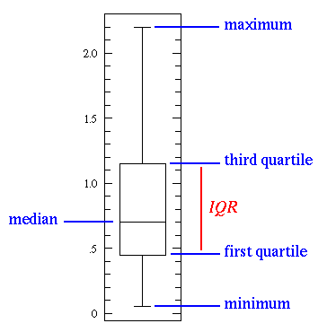

## Explore dataset

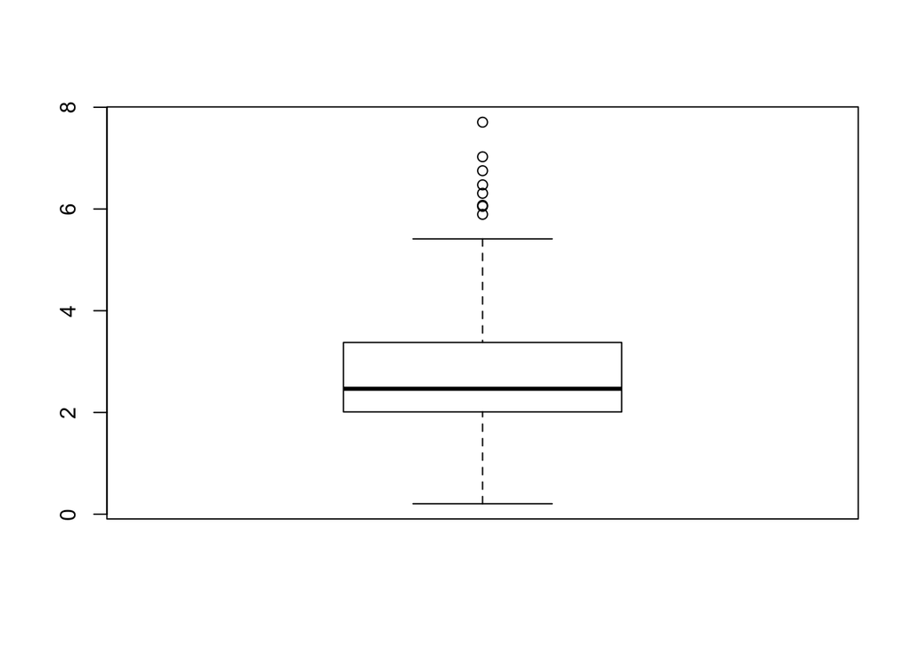

```r
boxplot(df$Global_active_power)
```

## Rename the column names

```r
names(df) <- c("date","time", "active_power", "reactive_power", "Voltage", "intensity", "Sub_met_1", "Sub_met_2", "Sub_met_3")
head(df)
```

```
##         date     time active_power reactive_power Voltage intensity
## 1 16/12/2006 17:24:00        4.216          0.418  234.84      18.4
## 2 16/12/2006 17:25:00        5.360          0.436  233.63      23.0
## 3 16/12/2006 17:26:00        5.374          0.498  233.29      23.0
## 4 16/12/2006 17:27:00        5.388          0.502  233.74      23.0
## 5 16/12/2006 17:28:00        3.666          0.528  235.68      15.8
## 6 16/12/2006 17:29:00        3.520          0.522  235.02      15.0
##   Sub_met_1 Sub_met_2 Sub_met_3
## 1         0         1        17
## 2         0         1        16
## 3         0         2        17
## 4         0         1        17
## 5         0         1        17
## 6         0         2        17
```

## Count the number of distinct date

See:

- ?length
- ?unique

```r
length(unique(df$date))
```

```
## [1] 2
```

## Check for duplicates record in the dataset

- if there are duplicates, verify how many
- create a new dataset containg only the duplicates records and save in a .csv file
- remove the duplicates from the original dataset

```r
dim(df[duplicated(df), ])
```

```
## [1] 3 9
```

```r
dup_df <- df[duplicated(df), ]
write.csv(dup_df, file="duplicates.csv")
df <- df[!duplicated(df), ]
dim(dup_df)
```

```
## [1] 3 9
```

```r
dim(df)
```

```
## [1] 800   9
```

## Check if there are records containing NA values

*`?complete.cases` Return a logical vector indicating which cases are complete, i.e., have no missing values.*

```r
head(complete.cases(df))
```

```
## [1] TRUE TRUE TRUE TRUE TRUE TRUE
```

```r
dim(df[!complete.cases(df),]) ##NOTE THE "!" that means NOT
```

```
## [1] 0 9
```

The result of `df[!complete.cases(df),]` is a dataframe containing all record with NA

## Check if there are records containing NA values

- Remove all values with NA (in the first toy dataset we used we replace NA with mean)

```r
df_withoutna <- df[complete.cases(df),] ##keep just complete records
```

- Verify the obtained result (the dimension of the dataset without NA is equal to dim(original dataframe) - dim(NAs) ?? )

```r
dim(df) ##Original datasets
```

```
## [1] 800   9
```

```r
dim(df[!complete.cases(df),]) ##records containing NAs
```

```
## [1] 0 9
```

```r
dim(df_withoutna) ##new datasets without NAs
```

```
## [1] 800   9
```

It’s a good pratice to make these type of checks to verify if your pre-processing steps are doing well.

## Add column to dataframe

- extract the “month” from the date field and add a column called “month”
- first convert the date object in the R object used to represent dates *as.POSIXct function*
- to extract the our use the function *as.POSIXlt function* (see ?as.POSIXlt)

```r
##The as.POSIXct functions convert the time object to the class used to represent times in R
##df_withoutna$month add a column month to the dataframe
df_withoutna$date <- as.POSIXct(df_withoutna$date, format = "%d/%m/%Y")

##add a field/column called month to the dataframe (remember that now we are working on the new dataframe "df_withoutna")
df_withoutna$month <- format(as.POSIXlt(df_withoutna$date), "%Y-%m")

#print an overview of the dataset
head(df_withoutna)
```

```
##         date     time active_power reactive_power Voltage intensity
## 1 2006-12-16 17:24:00        4.216          0.418  234.84      18.4
## 2 2006-12-16 17:25:00        5.360          0.436  233.63      23.0
## 3 2006-12-16 17:26:00        5.374          0.498  233.29      23.0
## 4 2006-12-16 17:27:00        5.388          0.502  233.74      23.0
## 5 2006-12-16 17:28:00        3.666          0.528  235.68      15.8
## 6 2006-12-16 17:29:00        3.520          0.522  235.02      15.0
##   Sub_met_1 Sub_met_2 Sub_met_3   month
## 1         0         1        17 2006-12
## 2         0         1        16 2006-12
## 3         0         2        17 2006-12
## 4         0         1        17 2006-12
## 5         0         1        17 2006-12
## 6         0         2        17 2006-12
```

## Aggregate values

Data can be aggregated in different ways, with different functions (length, mean, etc).

- *`?aggregate` function:* Splits the data into subsets, computes summary statistics for each, and returns the result in a convenient form.

*EXAMPLE 1* - Compute the average active_power per month (we ae aggregating by month) and save the result ina new dataframe “avg_active_power_xmonth”

```r
avg_active_power_xmonth <-  aggregate(active_power ~ month , df_withoutna, FUN=mean)
head(avg_active_power_xmonth)
```

```
##     month active_power
## 1 2006-12     2.552672
```

## Aggregate values

*EXAMPLE 2*

- Compute the number of active_power measurements per month (So, we are aggregating by month) and save the res in anew df “meas_xmonth”

```r
meas_xmonth <-  aggregate(date ~ month , df_withoutna, FUN=length)
names(meas_xmonth) <- c("month","meas_count")
head(meas_xmonth)
```

```
##     month meas_count
## 1 2006-12        800
```

R do not change the *column names* and this, sometimes, can be *misleading*; in that case it’s always better to rename the columns ( Rename the column names ).

## Sort dataframe by a specific column

```r
avg_active_power_xmonth <-  avg_active_power_xmonth[order(avg_active_power_xmonth$active_power),]
head(avg_active_power_xmonth)
```

```
##     month active_power
## 1 2006-12     2.552672
```

- Sort DESC

```r
avg_active_power_xmonth <-  avg_active_power_xmonth[order(-avg_active_power_xmonth$active_power),]
head(avg_active_power_xmonth)
```

```
##     month active_power
## 1 2006-12     2.552672
```

## Introduction to outliers

*“An outlier is an observation which deviates so much from the other observations as to arouse suspicions that it was generated by a different mechanism”[Hawkins 1980]*

There exist several ways to discover outliers. A first step may be to plot the values to see if there are objects that deviate significantly from the rest of the dataset.

*Example: See if there are outliers in the active power measurements of our dataset*

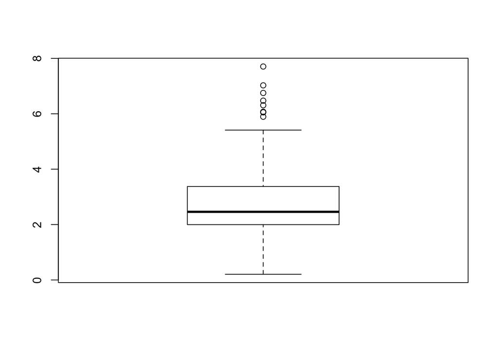

```r
boxplot(df_withoutna$active_power)
```

For more detalis about the outliers: https://www.siam.org/meetings/sdm10/tutorial3.pdf

## References

1. https://cran.r-project.org/doc/contrib/de_Jonge+van_der_Loo-Introduction_to_data_cleaning_with_R.pdf
2. https://www.coursera.org/learn/data-cleaning
3. https://www.coursera.org/learn/r-programming
4. http://www.r-bloggers.com
5. https://github.com/matteomanca/DataScienceSpCourseNotes/blob/master/2_RPROG/R_Programming_Course_Notes.pdf
6. https://www.siam.org/meetings/sdm10/tutorial3.pdf